# Homework 3 - BSTA 517

Matthew Hoctor

24 July, 2023

# Question 1

If we are given the probility of toxicity, $P$, as:

$$P = \mbox{expit}(\alpha + \beta \cdot
D)$$

Where $\alpha = -6.34$, $\beta = 5.25$, and $D$ is the dose. If we suppose that the target toxicity rate (TTR) is $1/3$, then we can find the maximum tolerated dose, $MTD$, by setting $P = 1/3$, and solving for $D$:

$$\begin{split}
D_{\mbox{max tolerated}} &= \frac{\mbox{logit}(P) - \alpha}{\beta}\\
&= \frac{\mbox{logit}(1/3) - -6.34}{5.25}\\
&= 1.076
\end{split}$$

```r
alpha <- -6.34
beta <- 5.25
TTR <- 1/3
func <- function(D){expit(alpha + beta*D)}
MTD <- (logit(TTR)-alpha)/beta
MTD
```

```
## [1] 1.075591
```

We can visualize this with the `ggplot` package:

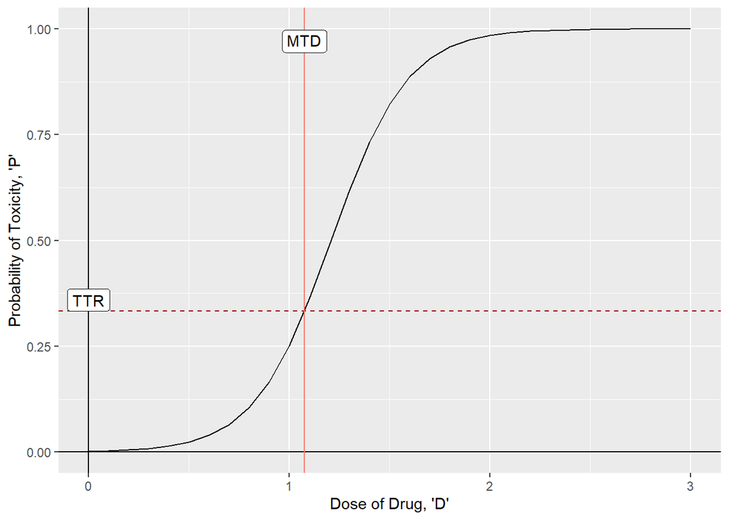

```r
p <- ggdistribution(func = func,
               x = seq(0, 3, 0.1),
               xlab = "Dose of Drug, 'D'",
               ylab = "Probability of Toxicity, 'P'")
p +
  geom_hline(aes(yintercept = TTR), colour="#990000", linetype="dashed", show.legend = FALSE) +
  geom_hline(aes(yintercept = 0), colour="black", linetype="solid", show.legend = FALSE) +
  geom_vline(aes(xintercept=MTD, colour="#990000", linetype="dashed", show.legend = FALSE)) +
  geom_vline(aes(xintercept = 0), colour="black", linetype="solid", show.legend = FALSE) +
  annotate(x=MTD,y=+Inf,label="MTD",vjust=2,geom="label") +
  annotate(x=0,y=TTR,label="TTR",vjust=0,geom="label") +
  theme(legend.position = "none")
```

# Question 2

## Probability of stopping early at stage 1

$$\begin{split}
\mbox{P} &= \sum_{i=0}^{r_1} \left( \begin{array}{c} n_1 \\ i
\end{array} \right) \pi^i (1-\pi)^{(n_1-i)}\\
\end{split}$$

This can be computed as:

```r
pbinom(15, size = 28, prob = 0.5)
```

```
## [1] 0.7142059
```

The probability of early termination (PET) for a trial of these parameters is 0.71; this is confirmed in Table 2 of the manuscript.

## Expected sample size

With these assumptions, and given the null hypothesis stated above, we can compute the expected sample size for Simon’s two-stage optimal design. We can estimate the expected sample size as $\mbox{E}(n) = n_1 + (1-\mbox{PET})n_2$ (this follows from the fact that the probability of proceeding to stage 2 and thereby recruiting $n_2$ patients is $1-\mbox{PET}$):

$$\begin{split}
\mbox{E}[n] &= n_1 + (1 - \mbox{PET}) n_2 \\
&=28 + 55\cdot(1-0.71)\\
&=43.95
\end{split}$$

Rounding up to the nearest whole participatnt, the expected value of the number of participants in this study is 44.

# Question 3

We can provide a continuous monitoring plan for the above two-stage phase II trial using the [Bayesian Toxicity Monitoring software on trialdesign.org](https://trialdesign.org/one-pageshell.html#BTOX) under the following set of assumptions:

1. If there is at least a $P_T = 0.75$ posterior probability of DLT, $\theta > 0.25$
2. Minimum patients enrolled before stopping early is 3

We can achieve this monitoring plan by setting the parameters in the user interface as $\theta_{max} = 0.25$, keep $a_0 = 0.5$ and $b_0 = 0.5$, max number of patients set to $83$, minimum patients before stopping early set to $3$, cohort size set to $1$, and $P_T = 0.75$. Exporting the report as an excel file allows us to display the results nicely:

The inputs:

```r
read_xlsx("BTOXv2.2.3.0_StoppingBoundariesReport.2023-07-24.xlsx",
          sheet = 1,
          skip = 4) |>
  flextable(cwidth = 2)
```

| Input Parameter | Input Value |
| --- | --- |
| Trial Name (Optional) |  |
| Maximum probability of Dose-limiting Toxicity allowed (theta) | 0.25 |
| Prior distribution for theta:Beta(a0,b0) a0 | 0.5 |
| Prior distribution for theta:Beta(a0,b0) b0 | 0.5 |
| Input Cohort Manually | FALSE |
| Maximum number of patients in the trial | 83 |
| Minimum number of patients before early stopping rule applies | 3 |
| Cohort size | 1 |
| Cohorts for interim analysis |  |
| Stop for excessive toxicity (PT) | 0.75 |

The Outputs:

```r
read_xlsx("BTOXv2.2.3.0_StoppingBoundariesReport.2023-07-24.xlsx",
          sheet = 3,
          range = "A2:B83") |>
flextable(cwidth = 1) |>
  align(align = "left")
```

| # Patients (inclusive) | # Toxicities (inclusive) are considered too toxic |
| --- | --- |
| 3 | 2 - 3 |
| 4 | 2 - 4 |
| 5 | 2 - 5 |
| 6 | 3 - 6 |
| 7 | 3 - 7 |
| 8 | 3 - 8 |
| 9 | 4 - 9 |
| 10 | 4 - 10 |
| 11 | 4 - 11 |
| 12 | 4 - 12 |
| 13 | 5 - 13 |
| 14 | 5 - 14 |
| 15 | 5 - 15 |
| 16 | 6 - 16 |
| 17 | 6 - 17 |
| 18 | 6 - 18 |
| 19 | 6 - 19 |
| 20 | 7 - 20 |
| 21 | 7 - 21 |
| 22 | 7 - 22 |
| 23 | 8 - 23 |
| 24 | 8 - 24 |
| 25 | 8 - 25 |
| 26 | 8 - 26 |
| 27 | 9 - 27 |
| 28 | 9 - 28 |
| 29 | 9 - 29 |
| 30 | 10 - 30 |
| 31 | 10 - 31 |
| 32 | 10 - 32 |

[output cut: 51 more lines]

# References

1. Simon R. Optimal two-stage designs for phase II clinical trials. Controlled Clinical Trials. 1989;10(1):1-10. doi:10.1016/0197-2456(89)90015-9